# Bessonov D. A. 1.4 31.05

…

31.05.2024

Начало сделал, как делали на семинарах, но еще пришлось сменить файл с данными, так как все данные были типа character, пришлось писать макросы (здесь я его написал, код в R не будет работать соответственно):

```
Sub ConvertYesNoToTrueFalse()
    Dim cell As Range
    Dim ws As Worksheet

    Set ws = ThisWorkbook.Sheets("shopping_trends_updated")

    For Each cell In ws.UsedRange
        If cell.Value = "Yes" Then
            cell.Value = True
        ElseIf cell.Value = "No" Then
            cell.Value = False
        End If
    Next cell

End Sub
Sub Convert_Text_to_NUmbers()
Selection.NumberFormat = "General"
Selection.Value = Selection.Value
End Sub
```

```r
library(dplyr)
library(ggplot2)
library(forcats)
library(readxl)
library(tidyverse)
library(naniar)
data <- read_excel("D:/clothesd.xlsm")
```

Наши переменные:

Customer ID - ID клиента Age - возраст клиента Gender - пол клиента (мужчина/женщина) Item Purchased - товар, купленный клиентом Category - категория товара Purchase Amount (USD) - сумма покупки Location - где была совершена покупка Size - размер товара Color - цвет товара Season - сезон покупки Review Rating - как клиент оценил товар Subscription Status - есть ли у клиента подписка (да/нет) Shipping Type - способ доставки Discount Applied - была ли применена скидка (да/нет) Promo Code Used - был ли применён промокод (да/нет) Previous Purchases - сколько покупок было у клиента до заказа Payment Method - способ оплаты Frequency of Purchases - как часто клиент совершает покупки (каждые три месяца, каждый год, каждый квартал, каждый месяц, каждые две недели)

```r
summary(data)
```

```
##   Customer ID          Age           Gender          Item Purchased
##  Min.   :   1.0   Min.   :18.00   Length:3900        Length:3900
##  1st Qu.: 975.8   1st Qu.:31.00   Class :character   Class :character
##  Median :1950.5   Median :44.00   Mode  :character   Mode  :character
##  Mean   :1950.5   Mean   :44.07
##  3rd Qu.:2925.2   3rd Qu.:57.00
##  Max.   :3900.0   Max.   :70.00
##    Category         Purchase Amount (USD)   Location             Size
##  Length:3900        Min.   : 20.00        Length:3900        Length:3900
##  Class :character   1st Qu.: 39.00        Class :character   Class :character
##  Mode  :character   Median : 60.00        Mode  :character   Mode  :character
##                     Mean   : 59.76
##                     3rd Qu.: 81.00
##                     Max.   :100.00
##     Color              Season          Review Rating  Subscription Status
##  Length:3900        Length:3900        Min.   :2.50   Mode :logical
##  Class :character   Class :character   1st Qu.:3.10   FALSE:2847
##  Mode  :character   Mode  :character   Median :3.70   TRUE :1053
##                                        Mean   :3.75
##                                        3rd Qu.:4.40
##                                        Max.   :5.00
##  Shipping Type      Discount Applied Promo Code Used Previous Purchases
##  Length:3900        Mode :logical    Mode :logical   Min.   : 1.00
##  Class :character   FALSE:2223       FALSE:2223      1st Qu.:13.00
##  Mode  :character   TRUE :1677       TRUE :1677      Median :25.00
##                                                      Mean   :25.35
##                                                      3rd Qu.:38.00
##                                                      Max.   :50.00
##  Payment Method     Frequency of Purchases
##  Length:3900        Length:3900
##  Class :character   Class :character
##  Mode  :character   Mode  :character
##
##
##
```

Далее посмотрел сколько уникальных значений в столбцах, чтобы присвоить им нужный тип данных, на семинарах мы проходили, что фактор хорошо делать для двух уникальных имен в переменных, я посмотрел несколько видео, решил, что для 7 и меньше также подойдет.

```r
unique(data$Size)
```

```
## [1] "L"  "S"  "M"  "XL"
```

```r
unique(data$Category)
```

```
## [1] "Clothing"    "Footwear"    "Outerwear"   "Accessories"
```

```r
unique(data$Season)
```

```
## [1] "Winter" "Spring" "Summer" "Fall"
```

```r
unique(data$`Frequency of Purchases`)
```

```
## [1] "Fortnightly"    "Weekly"         "Annually"       "Quarterly"
## [5] "Bi-Weekly"      "Monthly"        "Every 3 Months"
```

```r
unique(data$`Shipping Type`)
```

```
## [1] "Express"        "Free Shipping"  "Next Day Air"   "Standard"
## [5] "2-Day Shipping" "Store Pickup"
```

```r
unique(data$`Payment Method`)
```

```
## [1] "Venmo"         "Cash"          "Credit Card"   "PayPal"
## [5] "Bank Transfer" "Debit Card"
```

Присвоил данным нужные форматы:

```r
data$`Customer ID` = as.numeric(data$`Customer ID`)
data$Age = as.numeric(data$Age)
data$`Purchase Amount (USD)` = as.numeric(data$`Purchase Amount (USD)`)
data$`Review Rating` = as.numeric(data$`Review Rating`)
data$`Previous Purchases` = as.numeric(data$`Previous Purchases`)
data$Gender = as.factor(data$Gender)
data$Size = as.factor(data$Size)
data$Category = as.factor(data$Category)
data$Season = as.factor(data$Season)
data$`Frequency of Purchases` = as.factor(data$`Frequency of Purchases`)
data$`Shipping Type` = as.factor(data$`Shipping Type`)
data$`Payment Method` = as.factor(data$`Payment Method`)
data$`Subscription Status` = as.logical(data$`Subscription Status`)
data$`Discount Applied` = as.logical(data$`Discount Applied`)
data$`Promo Code Used` = as.logical(data$`Promo Code Used`)
```

Проверил на NA:

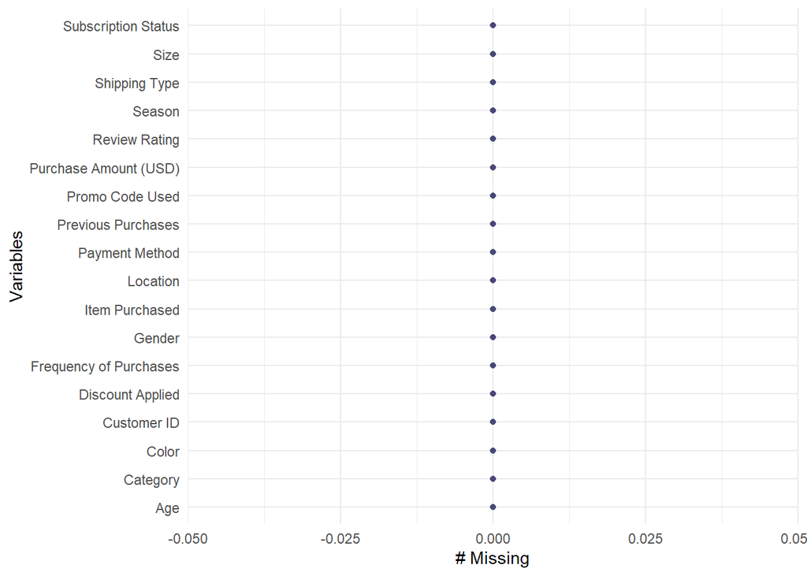

```r
gg_miss_var(data)
```

Проверил, все ли хорошо с данными, все ли типы правильны.

```r
summary(data)
```

```
##   Customer ID          Age           Gender     Item Purchased
##  Min.   :   1.0   Min.   :18.00   Female:1248   Length:3900
##  1st Qu.: 975.8   1st Qu.:31.00   Male  :2652   Class :character
##  Median :1950.5   Median :44.00                 Mode  :character
##  Mean   :1950.5   Mean   :44.07
##  3rd Qu.:2925.2   3rd Qu.:57.00
##  Max.   :3900.0   Max.   :70.00
##
##         Category    Purchase Amount (USD)   Location         Size
##  Accessories:1240   Min.   : 20.00        Length:3900        L :1053
##  Clothing   :1737   1st Qu.: 39.00        Class :character   M :1755
##  Footwear   : 599   Median : 60.00        Mode  :character   S : 663
##  Outerwear  : 324   Mean   : 59.76                           XL: 429
##                     3rd Qu.: 81.00
##                     Max.   :100.00
##
##     Color              Season    Review Rating  Subscription Status
##  Length:3900        Fall  :975   Min.   :2.50   Mode :logical
##  Class :character   Spring:999   1st Qu.:3.10   FALSE:2847
##  Mode  :character   Summer:955   Median :3.70   TRUE :1053
##                     Winter:971   Mean   :3.75
##                                  3rd Qu.:4.40
##                                  Max.   :5.00
##
##         Shipping Type Discount Applied Promo Code Used Previous Purchases
##  2-Day Shipping:627   Mode :logical    Mode :logical   Min.   : 1.00
##  Express       :646   FALSE:2223       FALSE:2223      1st Qu.:13.00
##  Free Shipping :675   TRUE :1677       TRUE :1677      Median :25.00
##  Next Day Air  :648                                    Mean   :25.35
##  Standard      :654                                    3rd Qu.:38.00
##  Store Pickup  :650                                    Max.   :50.00
##
##        Payment Method    Frequency of Purchases
##  Bank Transfer:612    Annually      :572
##  Cash         :670    Bi-Weekly     :547
##  Credit Card  :671    Every 3 Months:584
##  Debit Card   :636    Fortnightly   :542
##  PayPal       :677    Monthly       :553
##  Venmo        :634    Quarterly     :563
##                       Weekly        :539
```

Теперь про исследование и графики. Я решил, что проанализируем покупателей с подпиской и без подписки, так как это вполне реальная бизнес-задача, проанализировать данные по подписке и увеличить количество клиентов с подпиской. Не писал,откуда данные на графиках, так как сайт не известен, ссылку на файл вставлять не корректно. 1) График Сначала я построил column chart, который и отражает распределение статуса подписки у клиентов. Я считаю 27% клиентов, пользующихся подпиской,это очень хороший показатель, особенно для ритейла одежды.

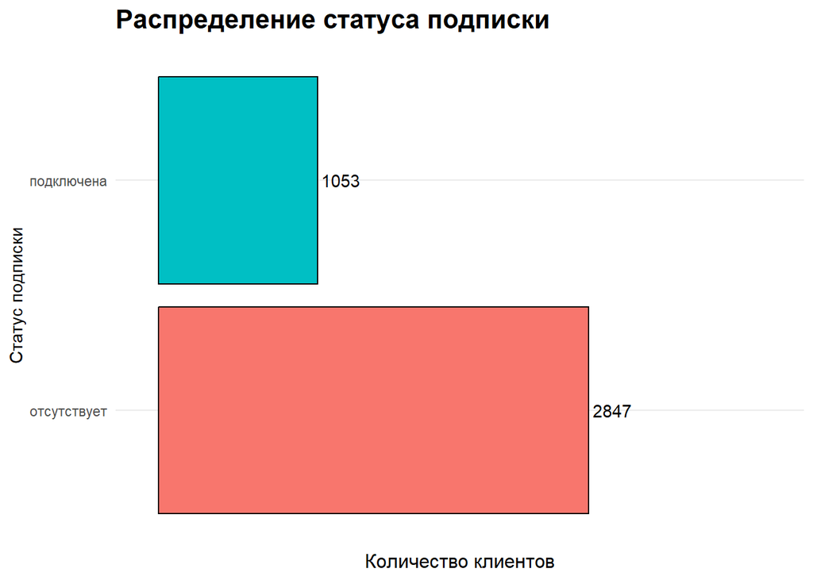

```r
data <- data %>%
  mutate(`Subscription Status` = ifelse(`Subscription Status`, "подключена", "отсутствует"))

ggplot(data, aes(y = `Subscription Status`, fill = `Subscription Status`)) +
  geom_bar(stat = "count", position = "stack", color = "black") +
  geom_text(stat = "count", aes(label = after_stat(count)), hjust = -0.1, color = "black") +
  labs(title = "Распределение статуса подписки",
       x = "Количество клиентов",
       y = "Статус подписки") +
  theme_minimal() +
  theme(axis.text.x = element_text(hjust = 0)) +
  scale_x_discrete(expand = expansion(mult = c(0.1, 0.5))) +
  theme(axis.title.x = element_text(size = 12, family = "Times New Roman")) +
  theme(plot.title = element_text(size = 16, family = "Times New Roman", face = "bold", hjust = 0)) +
  guides(fill = FALSE)
```

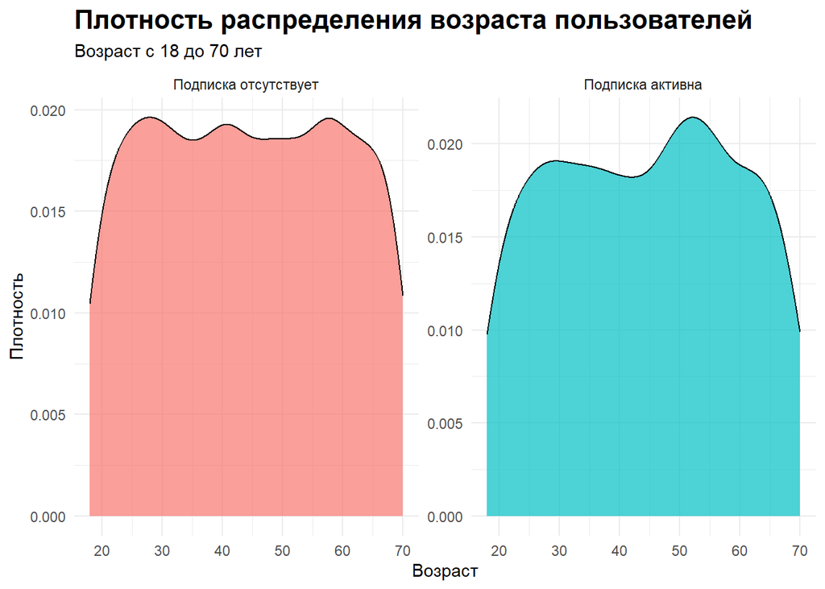

```r
data$`Subscription Status` <- factor(data$`Subscription Status`, labels = c("Подписка отсутствует", "Подписка активна"))

subscribed_users_data <- data[data$`Subscription Status` == "Подписка активна", ]

non_subscribed_users_data <- data[data$`Subscription Status` == "Подписка отсутствует", ]

ggplot(data, aes(x = Age, fill = `Subscription Status`)) +
  geom_density(alpha = 0.7) +
  facet_wrap(~`Subscription Status`, scales = "free_y") +
  labs(title = "Плотность распределения возраста пользователей", subtitle = "Возраст с 18 до 70 лет") +
  xlab("Возраст") +
  ylab("Плотность") +
  theme_minimal() +
  theme(legend.position = "none", text = element_text(family = "Times New Roman")) +
  theme(plot.title = element_text(size = 16, family = "Times New Roman", face = "bold", hjust = 0))
```

Примечание: не получилось сделать, чтобы куски pie chart были от большего к меньшему, и суммы в pie charts 100.2% и 99.9% из-за округления процентов.

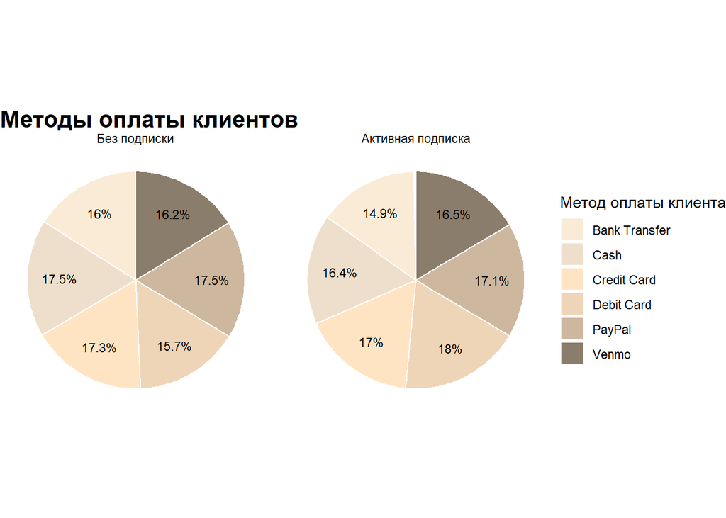

```r
data$`Subscription Status` <- factor(data$`Subscription Status`, labels = c(FALSE, TRUE))

payment_data <- data %>%
  group_by(`Subscription Status`, `Payment Method`) %>%
  summarise(Count = n()) %>%
  mutate(Percent = round(Count/sum(Count) * 100, 1))

payment_data <- payment_data %>%
  arrange(`Subscription Status`, desc(Count)) %>%
  group_by(`Subscription Status`) %>%
  mutate(Percent = round(Count/sum(Count) * 100, 1))

payment_data$`Subscription Status Label` <- factor(payment_data$`Subscription Status`, levels = c(FALSE, TRUE), labels = c("Без подписки", "Активная подписка"))

ggplot(payment_data, aes(x = "", y = Percent, fill = factor(`Payment Method`))) +
  geom_bar(stat = "identity", width = 1, color = "white") +
  geom_text(aes(label = paste0(Percent, "%"), x = 1.2), position = position_stack(vjust = 0.5), size = 3, family = "Times New Roman") +
  coord_polar("y") +
  labs(title = "Методы оплаты клиентов", fill = "Метод оплаты клиента", title1 = element_text(face = "bold", size = 14, family = "Times New Roman", hjust = 0)) +
  scale_fill_manual(values = c("Credit Card" = "#FFE4C4", "PayPal" = "#CDB79E", "Venmo" = "#8B7D6B", "Cash" = "#EEDFCC", "Bank Transfer" = "antiquewhite", "Debit Card" = "#EED5B7")) +
  theme_minimal() +
  facet_wrap(~`Subscription Status Label`) +
  theme_void() +  # Remove axis and background
  theme(plot.title = element_text(size = 16, family = "Times New Roman", face = "bold", hjust = 0))
```

4. График В конце я хотел узнать, покупают ли больше клиенты с подпиской. Снова оказался неправ.Графики почти схожи, но у клиентов без подписки чуть выше верхний квартиль, и чуть ниже нижний.

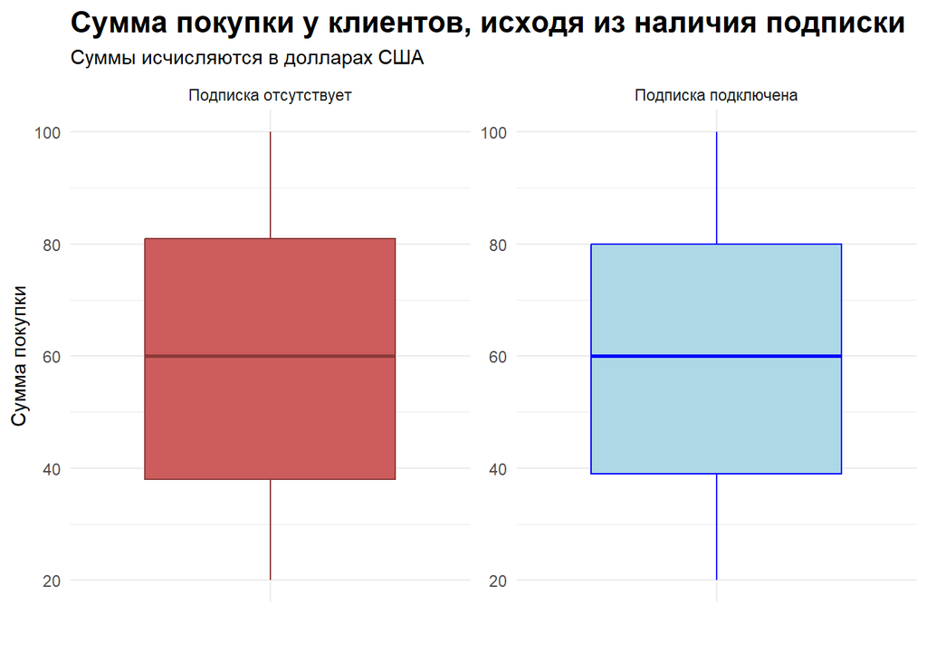

```r
theme_set(theme_minimal(base_family = "Times New Roman"))

data$`Subscription Status` <- factor(data$`Subscription Status`, labels = c("Подписка отсутствует", "Подписка подключена"))

subscribed_users_data <- data[data$`Subscription Status` == "Подписка подключена", ]
unsubscribed_users_data <- data[data$`Subscription Status` == "Подписка отсутствует", ]

ggplot(data, aes(x = '', y = `Purchase Amount (USD)`)) +
geom_boxplot(data = subscribed_users_data, fill = "lightblue", color = "blue") +
geom_boxplot(data = unsubscribed_users_data, fill = "#CD5C5C", color = "#8B3A3A") +
facet_wrap(~`Subscription Status`, scales = "free_y") +
labs( title = "Сумма покупки у клиентов, исходя из наличия подписки", title1 = element_text(face = "bold", size = 14, family = "Times New Roman"),
subtitle = "Суммы исчисляются в долларах США") +
theme_minimal() +
labs(x = "", y = "Сумма покупки") +
theme(plot.title = element_text(size = 16, family = "Times New Roman", face = "bold", hjust = 0))
```

Все выводы были описаны на промежуточных шагах.Конец.